# Module 6: Data Visualizations in R

- We can avoid this type of repetition by **passing a set of mappings to `ggplot()`**.
  - “ggplot2” will treat these mappings as global mappings that apply to each geom in the graph. In other words, this code will produce the same plot as the previous code:

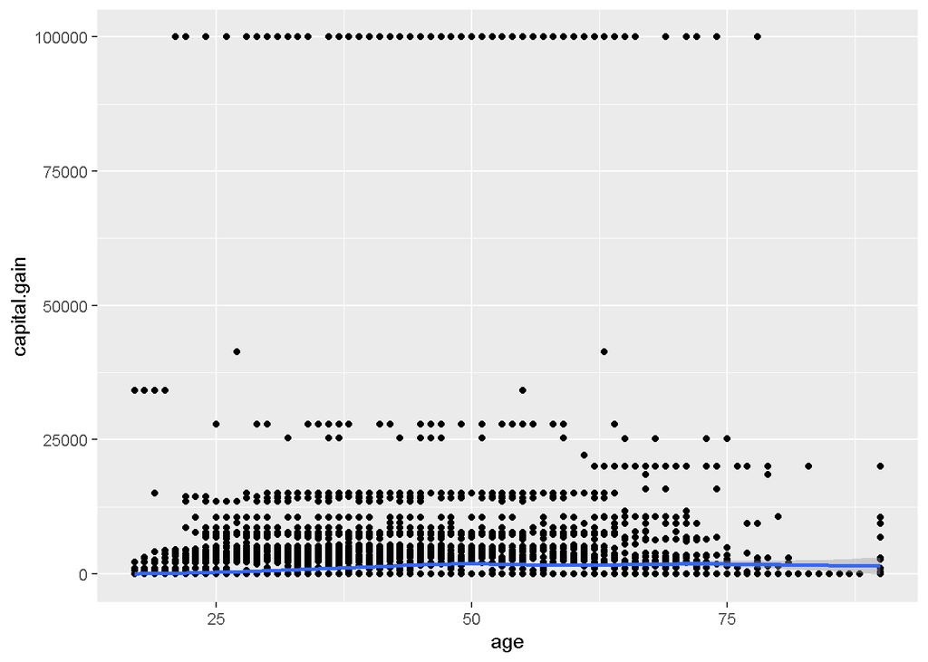

```r
ggplot(data = salary, mapping = aes(x = age, y = capital.gain)) +
  geom_point() +
  geom_smooth()
```

If we place mappings in a geom function, “ggplot2” will treat them as local mappings for the layer. It will use these mappings to extend or overwrite the global mappings *for that layer only*. This makes it possible to display different aesthetics in different layers.

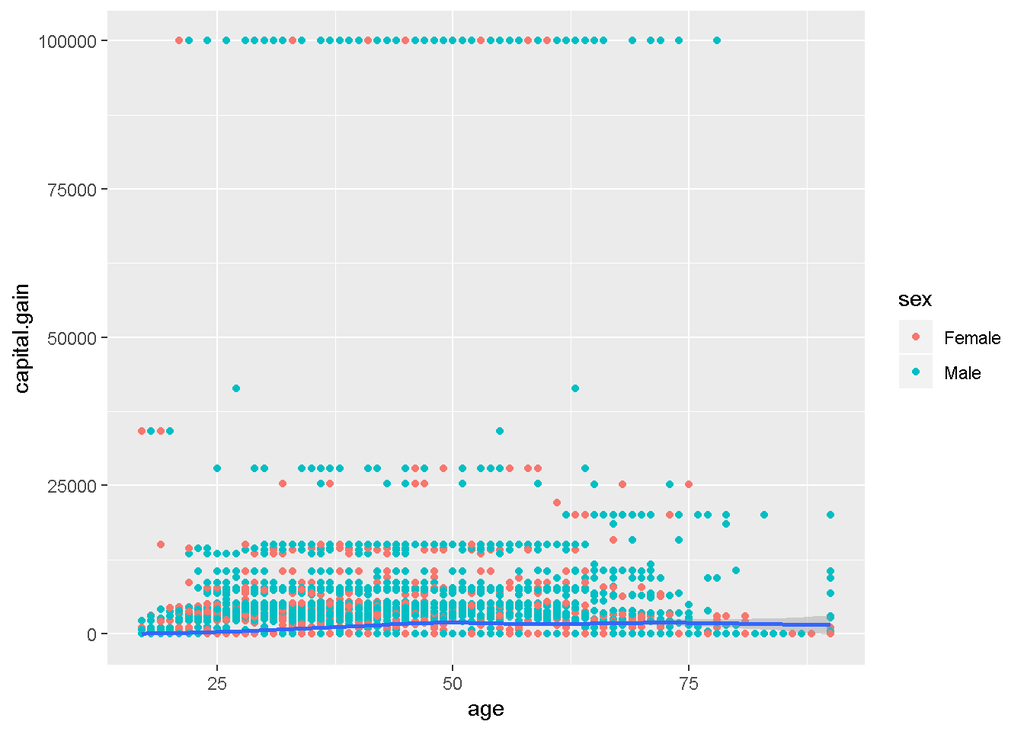

```r
ggplot(data = salary, mapping = aes(x = age, y = capital.gain)) +
  geom_point(mapping = aes(color = sex)) +
  geom_smooth()
```

## *ggplot2* & *tidyverse*

```r
library(tidyverse)
```

Now, let’s create a scatterplot but only for females in our data. To do so, we use tidyverse to filter the data and then we use ggplot2 to visualize the results:

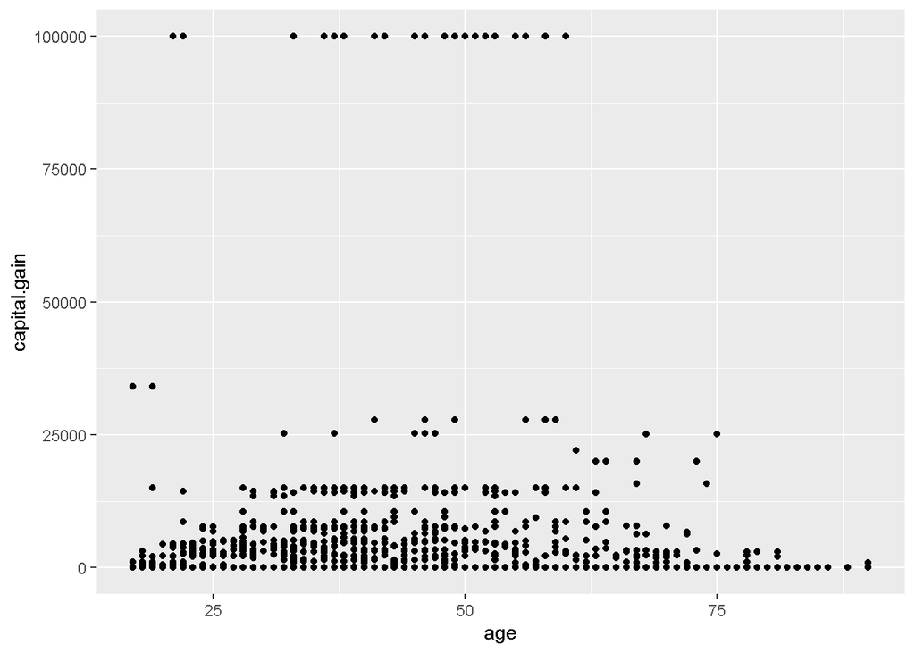

```r
salary %>%
  filter(sex == "Female") %>%
  ggplot(aes(x = age, y = capital.gain)) +
  geom_point()
```

Below, we create the histogram for female and males separately:

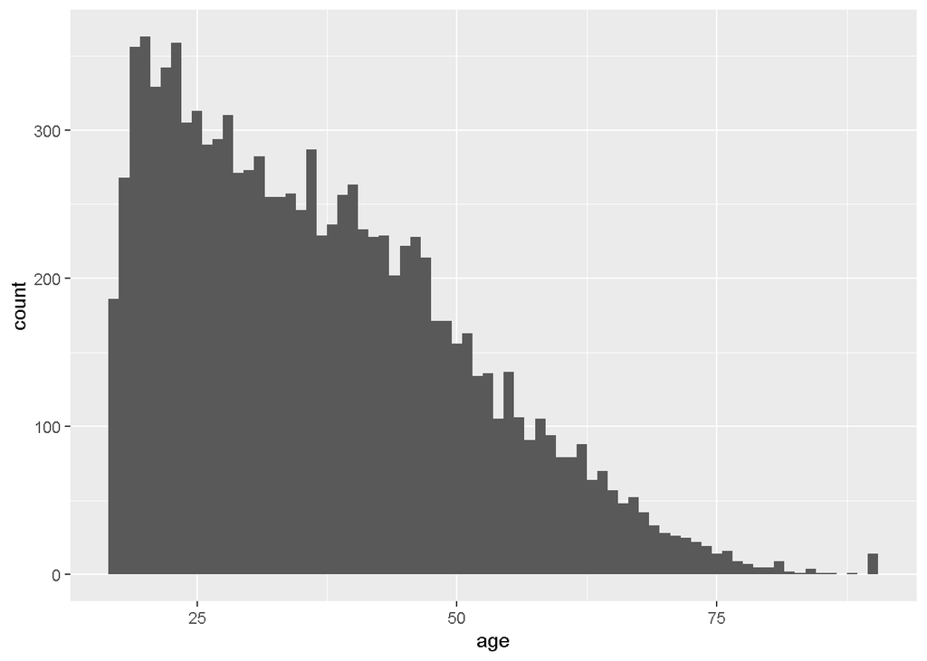

```r
salary %>%
  filter(sex == "Female") %>%
  ggplot(aes(x = age)) +
  geom_histogram(binwidth = 1)
```

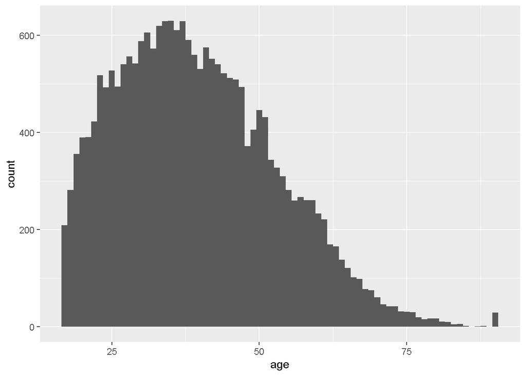

```r
salary %>%
  filter(sex == "Male") %>%
  ggplot(aes(x = age)) +
  geom_histogram(binwidth = 1)
```

Let’s add some title to our plots:

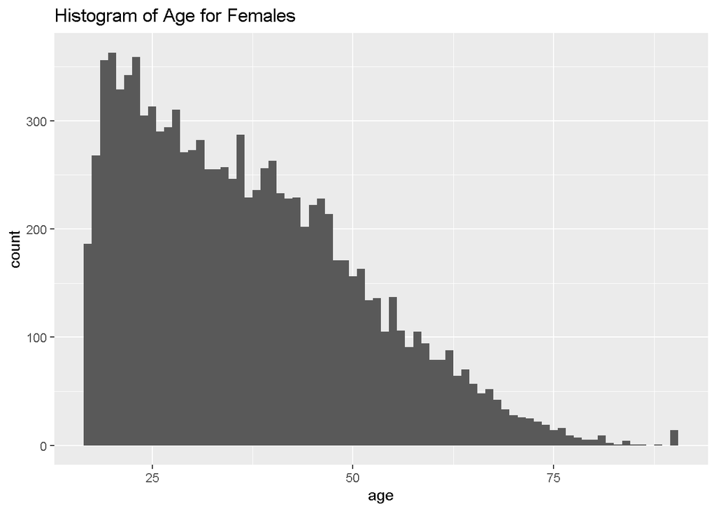

```r
salary %>%
  filter(sex == "Female") %>%
  ggplot(aes(x = age)) +
  geom_histogram(binwidth = 1) +
  ggtitle("Histogram of Age for Females")
```

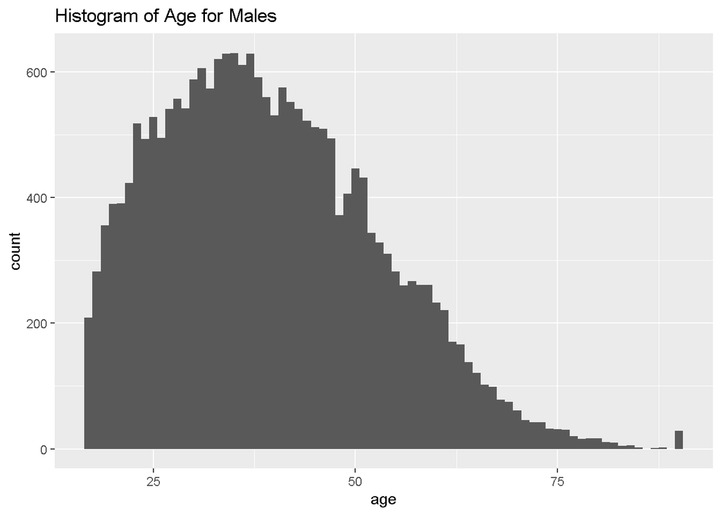

```r
salary %>%
  filter(sex == "Male") %>%
  ggplot(aes(x = age)) +
  geom_histogram(binwidth = 1) +
  ggtitle("Histogram of Age for Males")
```

Imagine that we wanted to create a visualization to show the capital gains broken by education level-

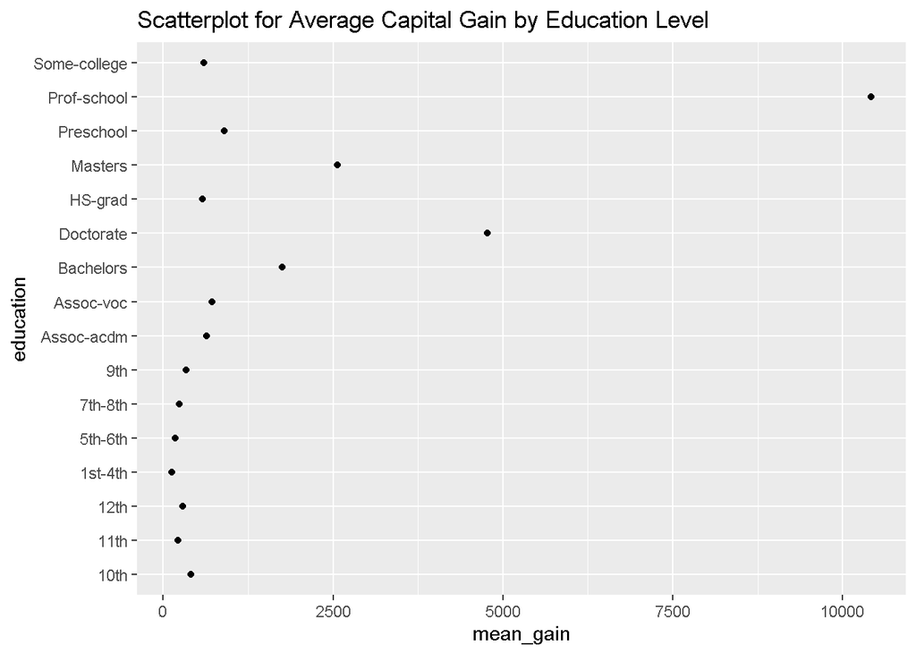

```r
salary %>%
  group_by(education) %>%
  summarise(mean_gain = mean(capital.gain, na.rm = T)) %>%
  ggplot(aes(x = mean_gain, y = education)) +
  geom_point() +
  ggtitle("Scatterplot for Average Capital Gain by Education Level")
```

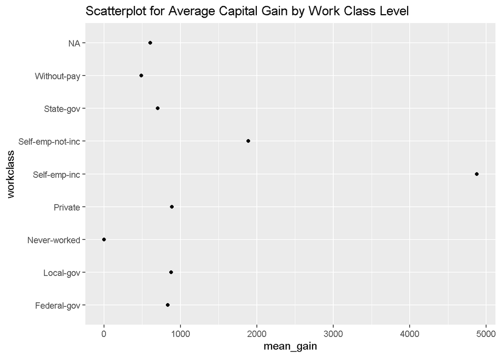

```r
salary %>%
  group_by(workclass) %>%
  summarise(mean_gain = mean(capital.gain, na.rm = T)) %>%
  ggplot(aes(x = mean_gain, y = workclass)) +
  geom_point() +
  ggtitle("Scatterplot for Average Capital Gain by Work Class Level")
```

## **Statistical Transformations**

Consider a basic bar chart, as drawn with `geom_bar()`:

```r
p1 +
  geom_bar(mapping = aes(x = education)) +
  coord_flip()
```

[output not shown]

- **bar charts, histograms, and frequency polygons** bin our data and then plot bin counts, the number of points that fall in each bin.
- **smoothers** fit a model to our data and then plot predictions from the model.
- **boxplots** compute a robust summary of the distribution and then display a specially formatted box.

The algorithm used to calculate new values for a graph is called a **stat**, short for statistical transformation. We can learn which stat a geom uses by inspecting the default value for the `stat` argument. For example, `?geom_bar` shows that the default value for `stat` is “count”, which means that `geom_bar()` uses `stat_count()`. `stat_count()` is documented on the same page as `geom_bar()`, and if we scroll down we can find a section called “Computed variables”. That describes how it computes two new variables: `count` and `prop`.

We can **generally use geoms and stats interchangeably**. For example, we can recreate the previous plot using `stat_count()` instead of `geom_bar()`:

```r
p1 +
  stat_count(mapping = aes(x = education)) +
  coord_flip()
```

[output not shown]

This works because **every geom has a default stat; and every stat has a default geom.** This means that we can typically use geoms without worrying about the underlying statistical transformation. But we could change the stats if wanted to. For instance, we use proportions instead of count:

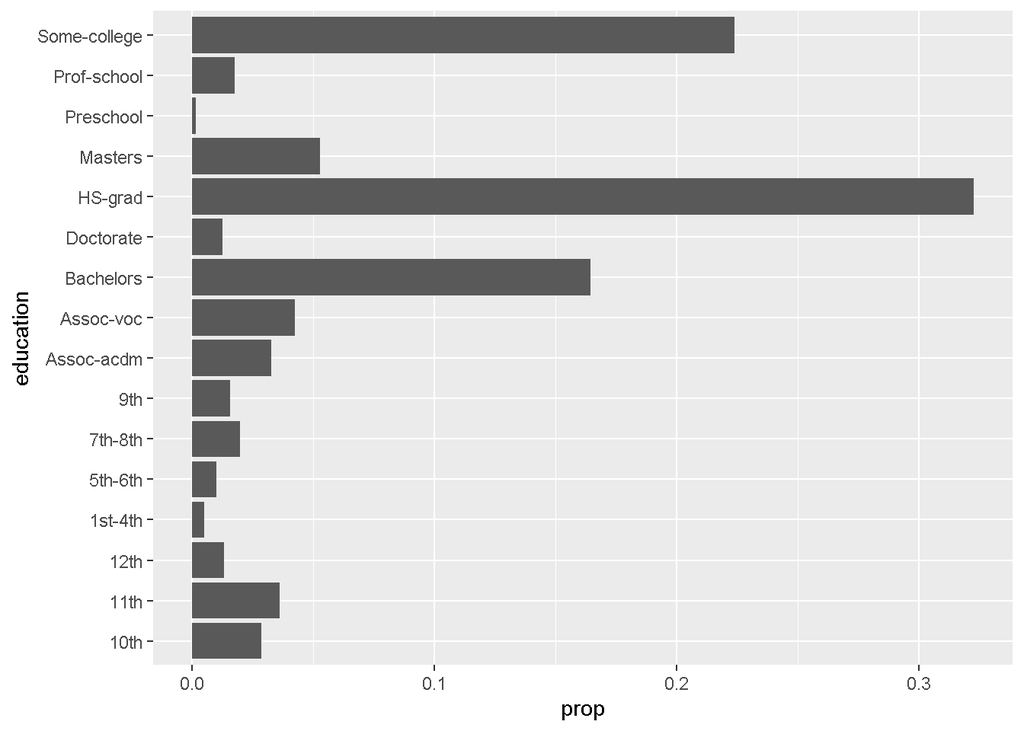

```r
p1 +
  geom_bar(mapping = aes(x = education, y = ..prop.., group = 1)) +
  coord_flip()
```

The plot shows that for instance over 30% of observations have HS-grad as the value of education.

We might want to draw greater attention to the statistical transformation in our code. For example, we can use `stat_summary()`, which summarises the y values for each unique x value, to draw attention to the summary that we’re computing:

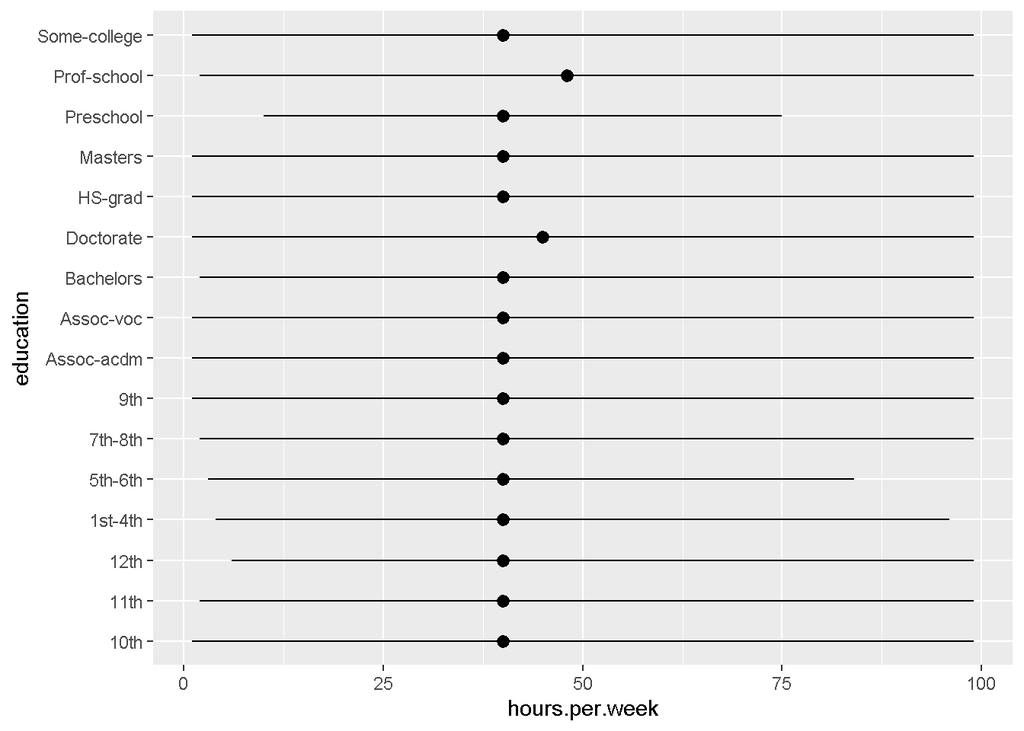

```r
p1 +
  stat_summary(
    mapping = aes(x = education, y = hours.per.week),
    fun.ymin = min,
    fun.ymax = max,
    fun.y = median
  ) +
  coord_flip()
```

“ggplot2” provides over 20 stats. Each stat is a function, so we can get help in the usual way, e.g. `?stat_bin`. To see a complete list of stats, we can try the “ggplot2” cheatsheet

## **Position Adjustments**

1- Setting `position` to `identity` creates the following plot:

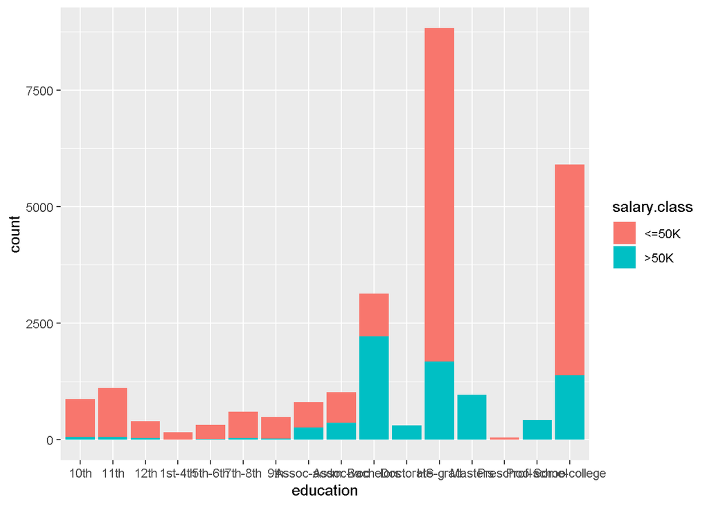

```r
p1 +
  geom_bar(mapping = aes(x = education, fill = salary.class), position = "identity")
```

2- `position = "fill"` works like stacking, but makes each set of stacked bars the same height. This makes it easier to compare proportions across groups.

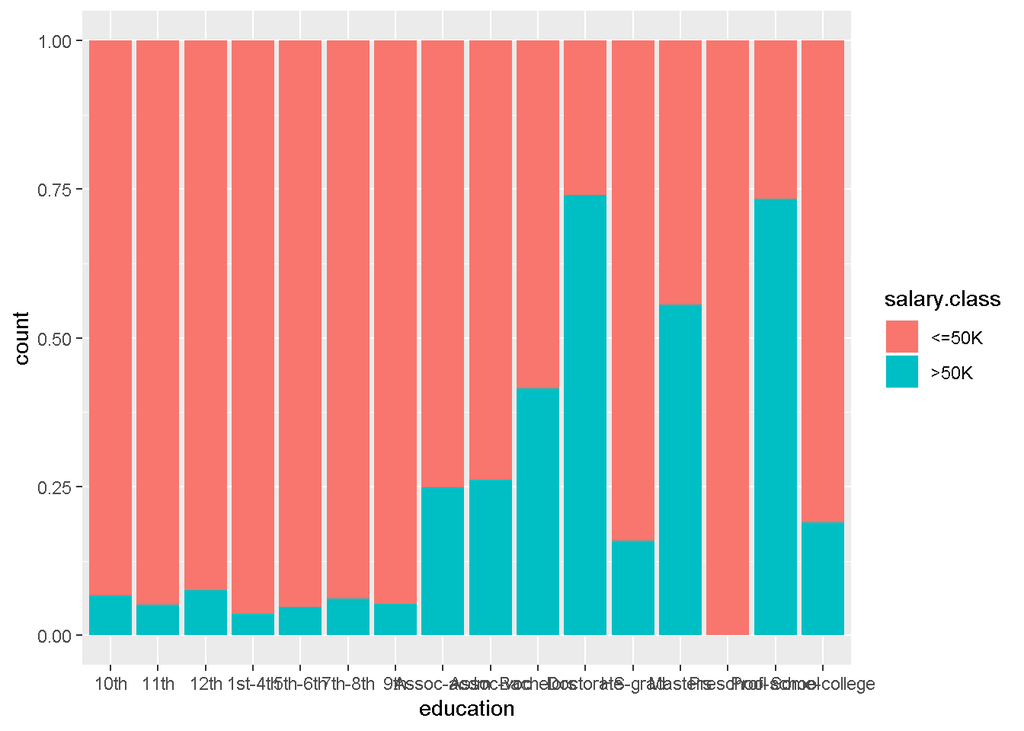

```r
p1 +
  geom_bar(mapping = aes(x = education, fill = salary.class), position = "fill")
```

3- `position = "dodge"` places overlapping objects directly beside one another. This makes it easier to compare individual values.

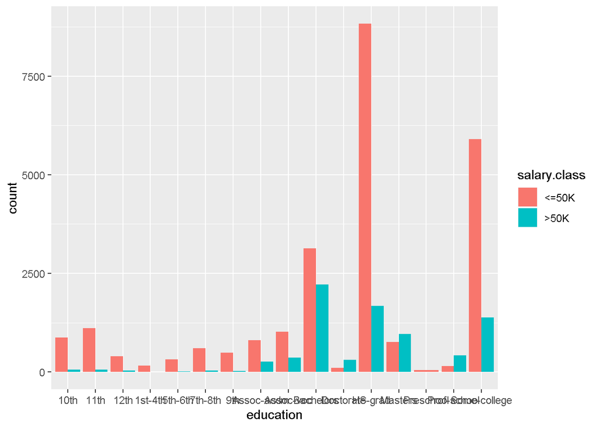

```r
p1 +
  geom_bar(mapping = aes(x = education, fill = salary.class), position = "dodge")
```

There’s one other type of adjustment that’s not useful for bar charts, but it can be very useful for scatterplots. Let’s take a look at the following scatterplot:

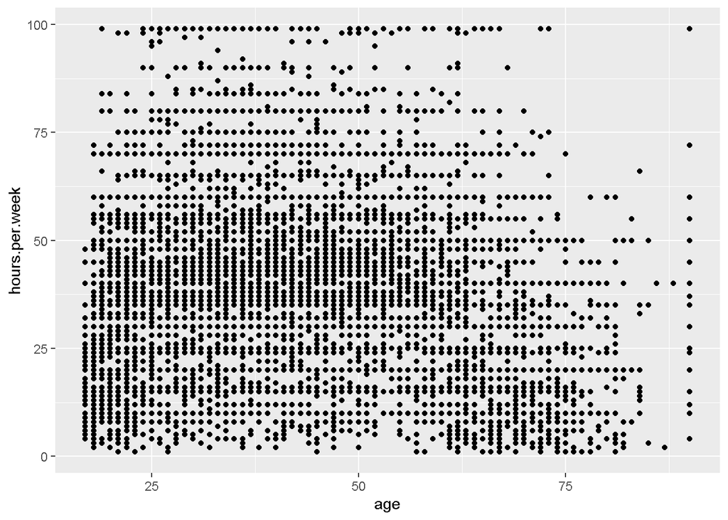

```r
p1 +
  geom_point(mapping = aes(x = age, y = hours.per.week))
```

The values of `age` and `hours.per.week` are rounded so the points appear on a grid and many points overlap each other. This problem is known as **overplotting**. We can avoid this gridding by setting the position adjustment to “jitter”.

- **`position = "jitter"` adds a small amount of random noise to each point.**
- This spreads the points out because no two points are likely to receive the same amount of random noise.

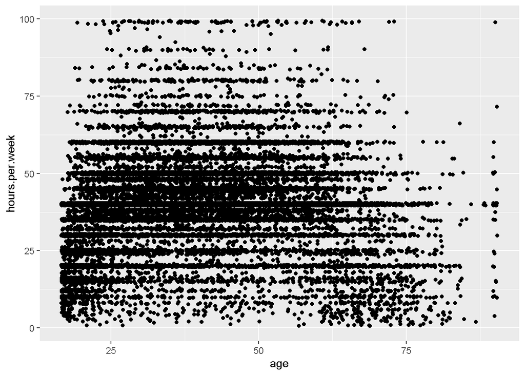

```r
p1 +
  geom_point(mapping = aes(x = age, y = hours.per.week), position = "jitter")
```

Adding randomness seems like a strange way to improve our plot, but while it makes our graph less accurate at small scales, it makes it more revealing at large scales. Because this is such a useful operation, **“ggplot2” comes with a shorthand for `geom_point(position = "jitter")`: `geom_jitter()`.**

To learn more about a position adjustment, look up the help page associated with each adjustment: `?position_dodge`, `?position_fill`, `?position_identity`, `?position_jitter`, and `?position_stack`.

## **Coordinate systems**

We have already discussed why in certain cases we need to flip the coordinates:

1- `coord_flip()` switches the x and y axes. This is useful (for example), if we want horizontal boxplots. It’s also useful for long labels: it’s hard to get them to fit without overlapping on the x-axis.

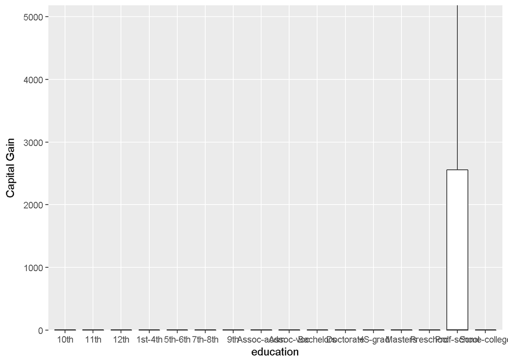

```r
p1 +
  geom_boxplot(aes(x = education, y = capital.gain), outlier.shape=NA) +
  scale_y_discrete(name ="Capital Gain",
                    limits=seq(0,20000,1000))
```

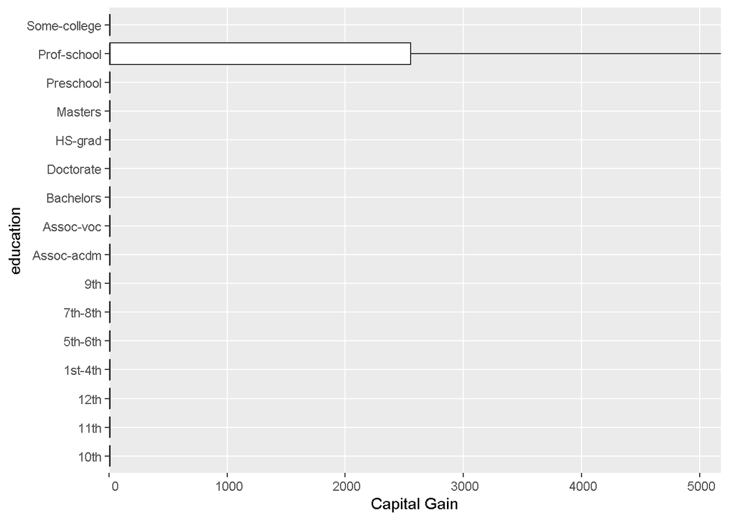

```r
p1 +
  geom_boxplot(aes(x = education, y = capital.gain), outlier.shape=NA) +
  scale_y_discrete(name ="Capital Gain",
                    limits=seq(0,20000,1000)) +
  coord_flip()
```

2- `coord_quickmap()` sets the aspect ratio correctly for maps. This is very important if we’re plotting spatial data with “ggplot2”.

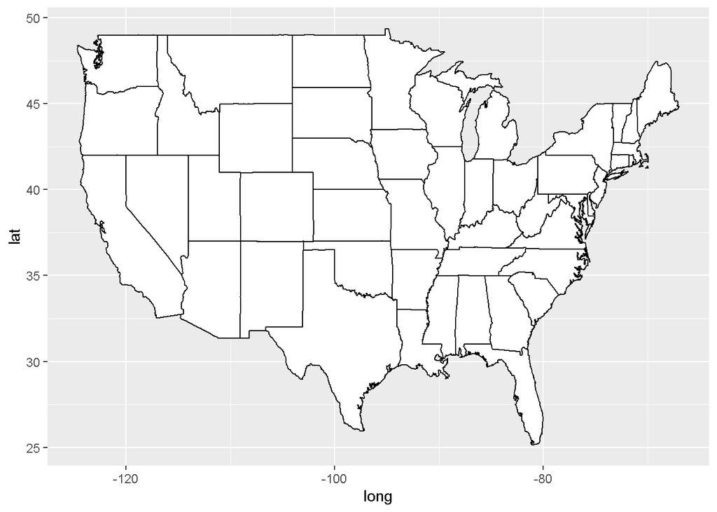

```r
# install.packages("maps")
library(maps)
us <- map_data("state")

ggplot(us, aes(long, lat, group = group)) +
geom_polygon(fill = "white", colour = "black")
```

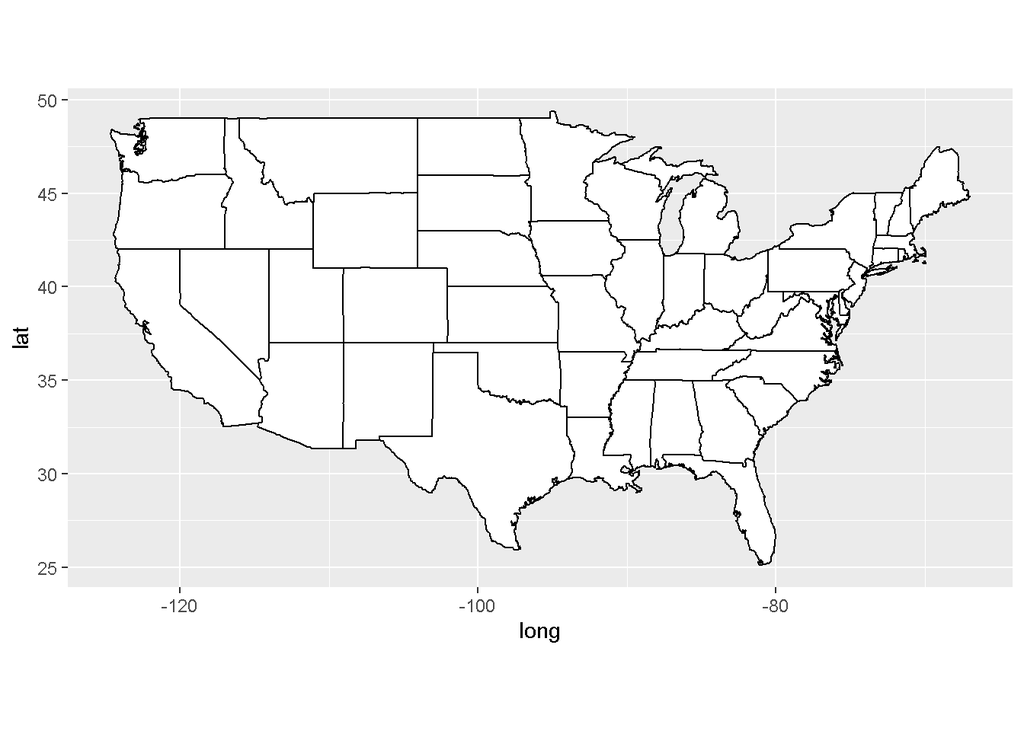

```r
ggplot(us, aes(long, lat, group = group)) +
 geom_polygon(fill = "white", colour = "black") +
 coord_quickmap()
```

3- `coord_polar()` uses polar coordinates. Polar coordinates reveal an interesting connection between a bar chart and a Coxcomb chart.

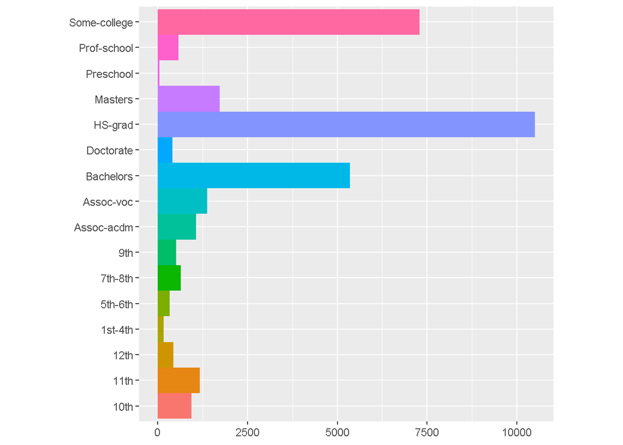

```r
p2 <- p1 +
  geom_bar(
    mapping = aes(x = education, fill = education),
    show.legend = FALSE,
    width = 1
  ) +
  theme(aspect.ratio = 1) +
  labs(x = NULL, y = NULL)

p2 + coord_flip()
```

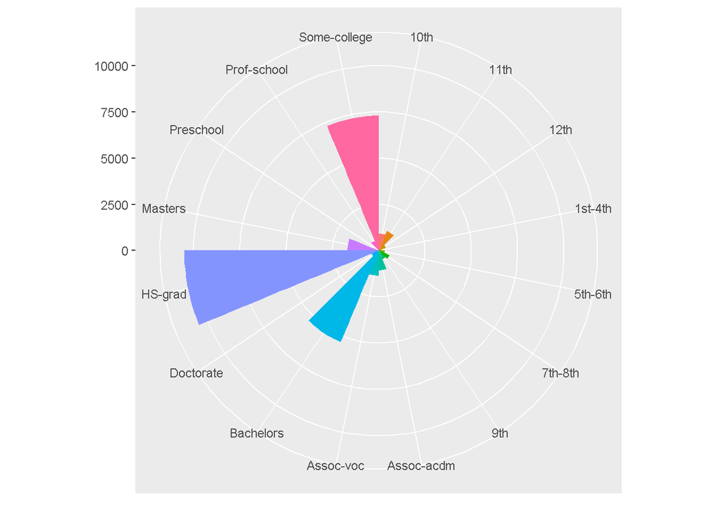

```r
p2 + coord_polar()
```

## **The Layered Grammar of Graphics**

In the previous sections, we learned a foundation that we can use to make any type of plot with “ggplot2”. To see this, let’s add position adjustments, stats, coordinate systems, and faceting to our code template:

```
ggplot(data = <DATA>) +
  <GEOM_FUNCTION>(
     mapping = aes(<MAPPINGS>),
     stat = <STAT>,
     position = <POSITION>
  ) +
  <COORDINATE_FUNCTION> +
  <FACET_FUNCTION>
```

Our new template takes seven parameters, the bracketed words that appear in the template. In practice, we rarely need to supply all seven parameters to make a graph because “ggplot2” will provide useful defaults for everything except the data, the mappings, and the geom function.

The seven parameters in the template compose the grammar of graphics, a formal system for building plots. The grammar of graphics is based on the insight that we can uniquely describe any plot as a combination of a dataset, a geom, a set of mappings, a stat, a position adjustment, a coordinate system, and a faceting scheme.

*Source:* https://r4ds.had.co.nz/data-visualisation.html

References:

1. https://psu-psychology.github.io/r-bootcamp-2019/talks/ggplot_grammar.html